# What Factors Most Impact Student Performance?

Here we create two functions that plot the mean and standard deviation of each factor against the dependent variable, which is the final grade, using a bar graph. The only difference between the two is that one is for the Portuguese dataset, while the other is for the Math dataset.

```python
def plot_por_attribute(attribute):

    plt.title('Final Portuguese Grades by ' + attribute)
    plt.xlabel(attribute)
    plt.ylabel('Final Grades')

    attributes = por_dataframe[attribute].unique()
    for att in attributes:
        filtered = por_dataframe[por_dataframe[attribute] == att]

        mean = filtered['Portuguese Final Grade'].mean()
        std = filtered['Portuguese Final Grade'].std()

        plt.bar(att, mean)
        plt.bar(att, std)

    plt.show()

def plot_math_attribute(attribute):

    plt.title('Final Math Grades by ' + attribute)
    plt.xlabel(attribute)
    plt.ylabel('Final Grades')

    attributes = math_dataframe[attribute].unique()
    for att in attributes:
        filtered = math_dataframe[math_dataframe[attribute] == att]

        mean = filtered['Math Final Grade'].mean()
        std = filtered['Math Final Grade'].std()

        plt.bar(att, mean)
        plt.bar(att, std)

    plt.show()
```

Now we plot each factor from both datasets against the final grades so we can visually see which factor impacts the grade the most.

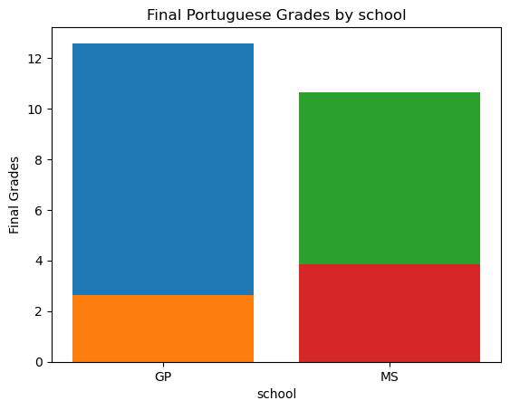

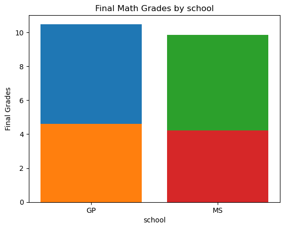

```python
plot_por_attribute('school')
plot_math_attribute('school')
```

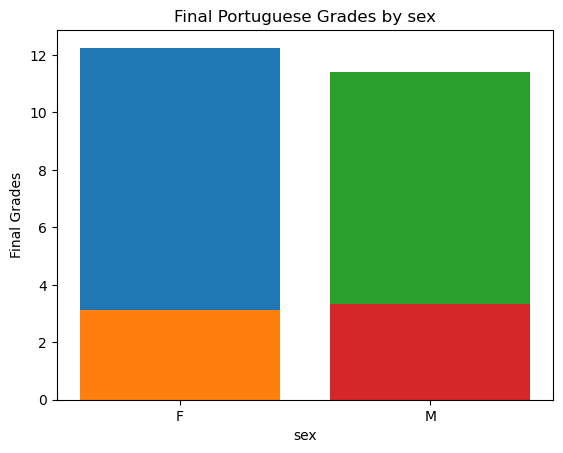

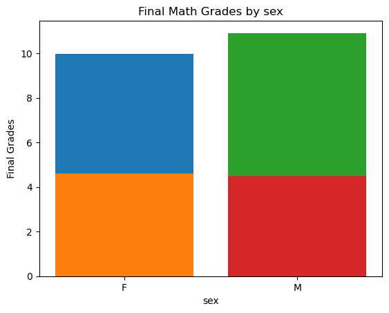

```python
plot_por_attribute('sex')
plot_math_attribute('sex')
```

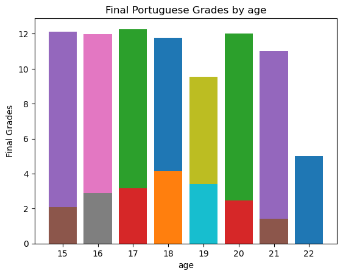

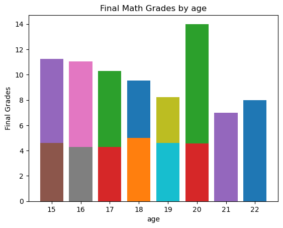

```python
plot_por_attribute('age')
plot_math_attribute('age')
```

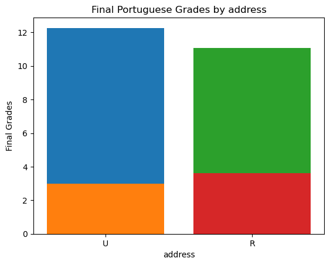

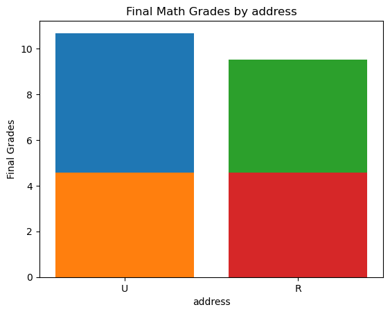

```python
plot_por_attribute('address')
plot_math_attribute('address')
```

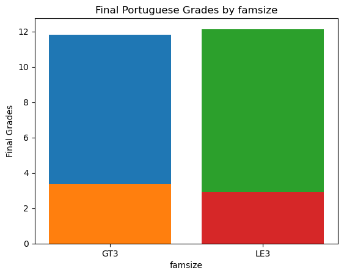

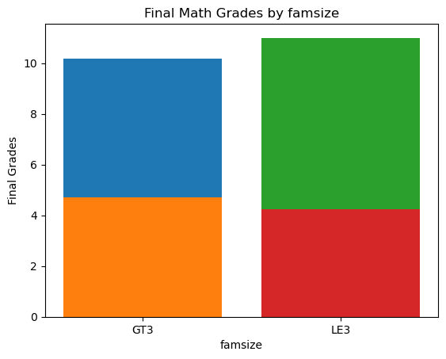

```python
plot_por_attribute('famsize')
plot_math_attribute('famsize')
```

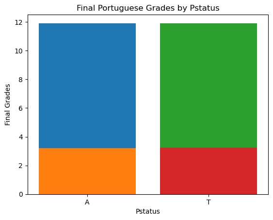

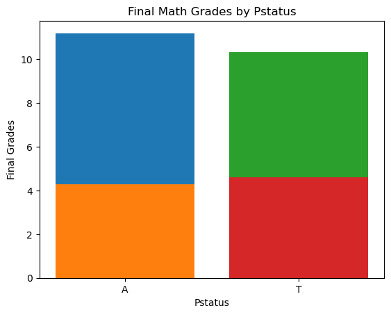

```python
plot_por_attribute('Pstatus')
plot_math_attribute('Pstatus')
```

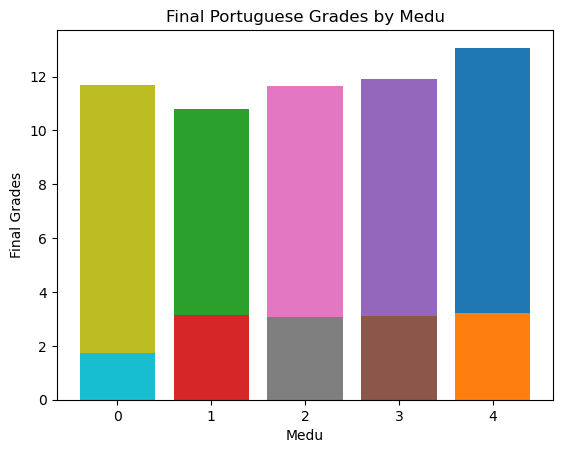

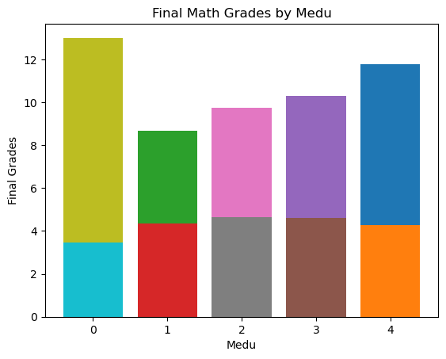

```python
plot_por_attribute('Medu')
plot_math_attribute('Medu')
```

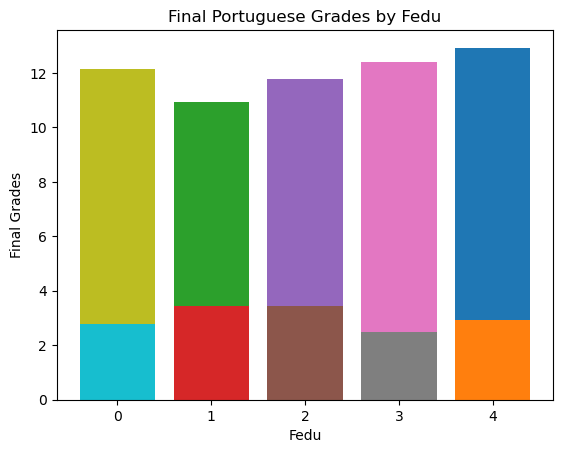

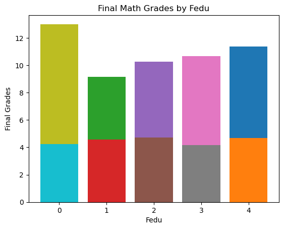

```python
plot_por_attribute('Fedu')
plot_math_attribute('Fedu')
```

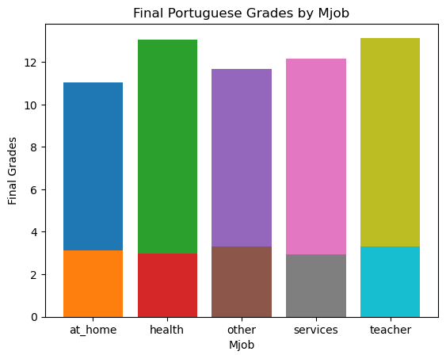

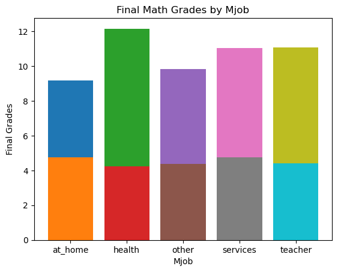

```python
plot_por_attribute('Mjob')
plot_math_attribute('Mjob')
```

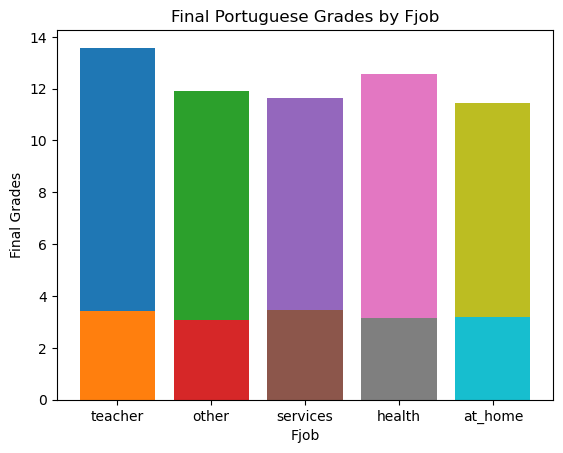

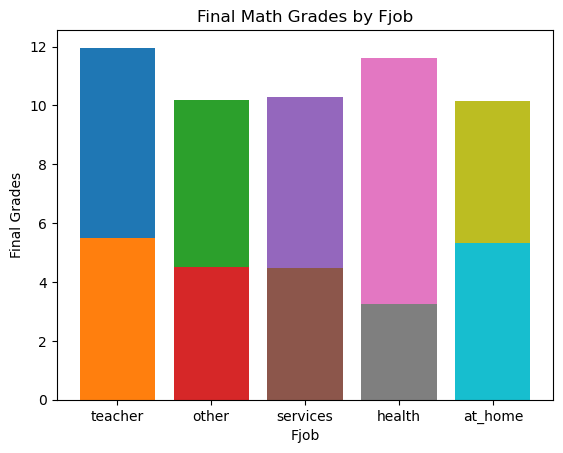

```python
plot_por_attribute('Fjob')
plot_math_attribute('Fjob')
```

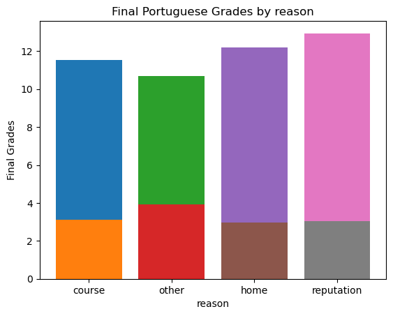

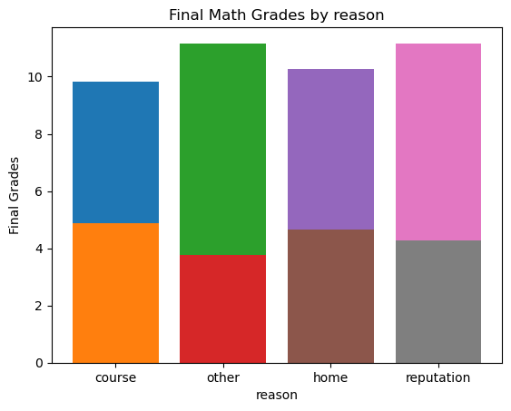

```python
plot_por_attribute('reason')
plot_math_attribute('reason')
```

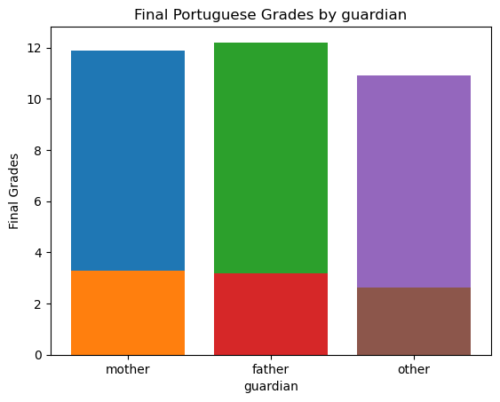

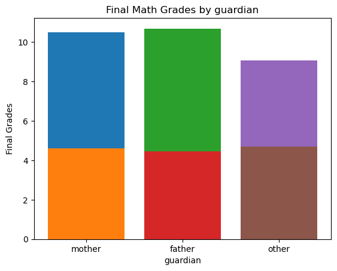

```python
plot_por_attribute('guardian')
plot_math_attribute('guardian')
```

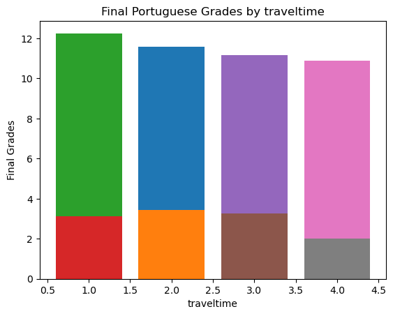

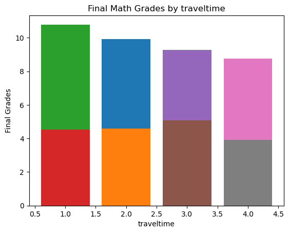

```python
plot_por_attribute('traveltime')
plot_math_attribute('traveltime')
```

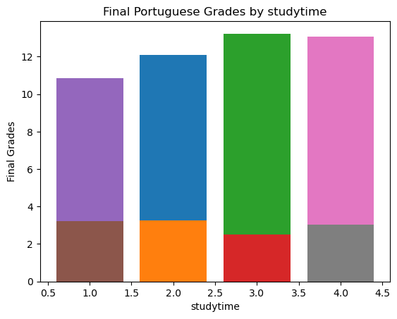

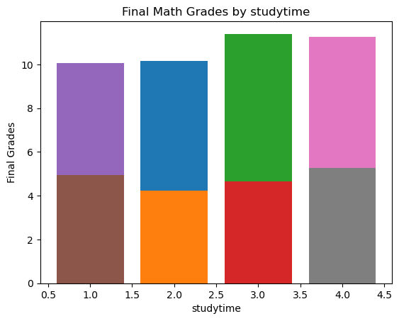

```python
plot_por_attribute('studytime')
plot_math_attribute('studytime')
```

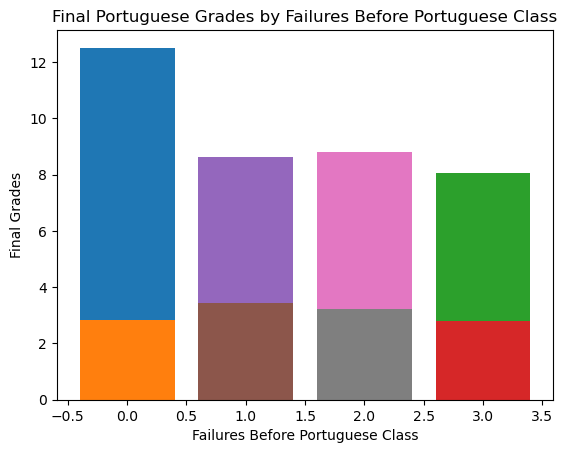

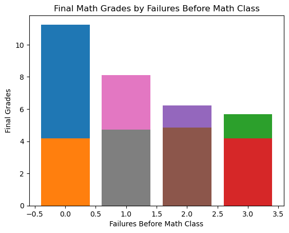

```python
plot_por_attribute('Failures Before Portuguese Class')
plot_math_attribute('Failures Before Math Class')
```

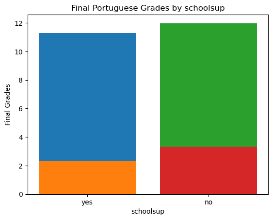

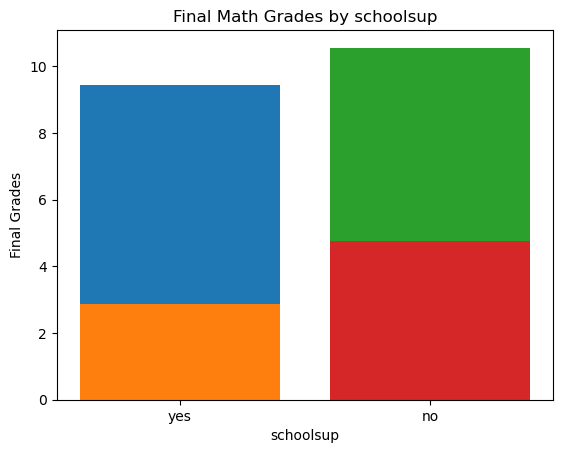

```python
plot_por_attribute('schoolsup')
plot_math_attribute('schoolsup')
```

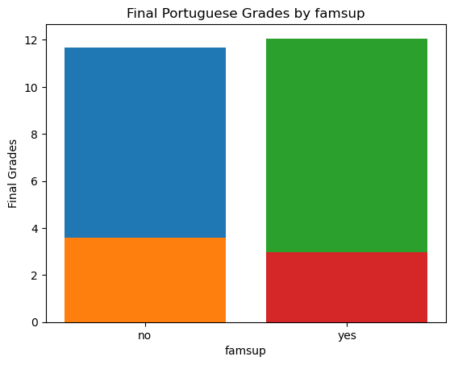

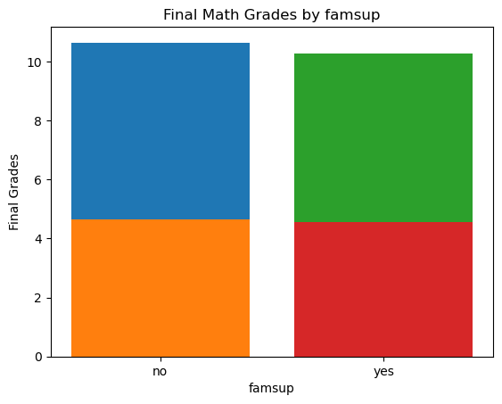

```python
plot_por_attribute('famsup')
plot_math_attribute('famsup')
```

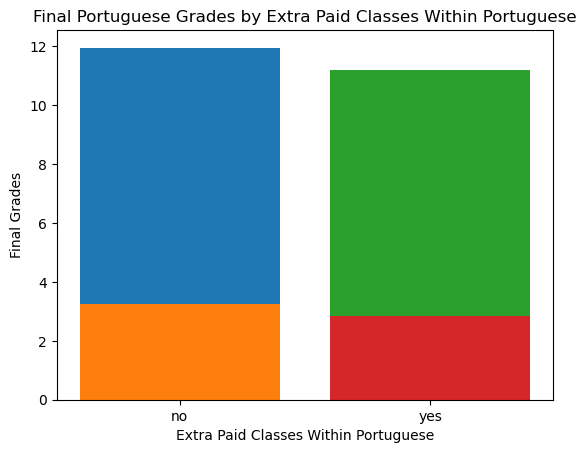

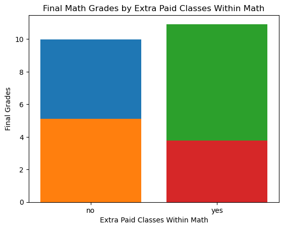

```python
plot_por_attribute('Extra Paid Classes Within Portuguese')
plot_math_attribute('Extra Paid Classes Within Math')
```

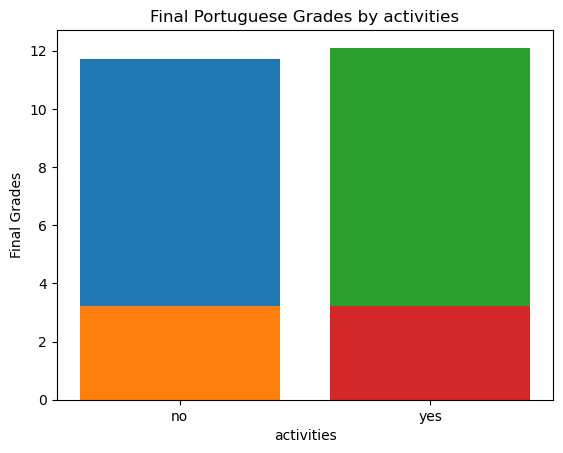

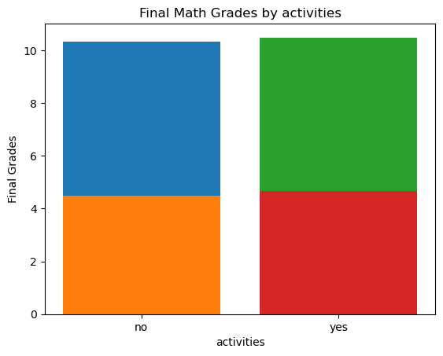

```python
plot_por_attribute('activities')
plot_math_attribute('activities')
```

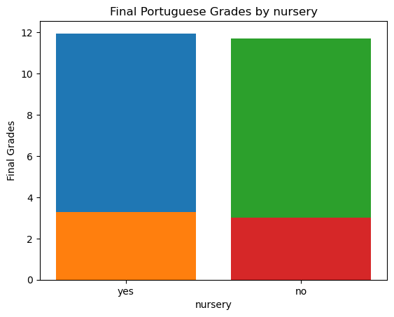

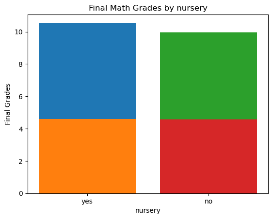

```python
plot_por_attribute('nursery')
plot_math_attribute('nursery')
```

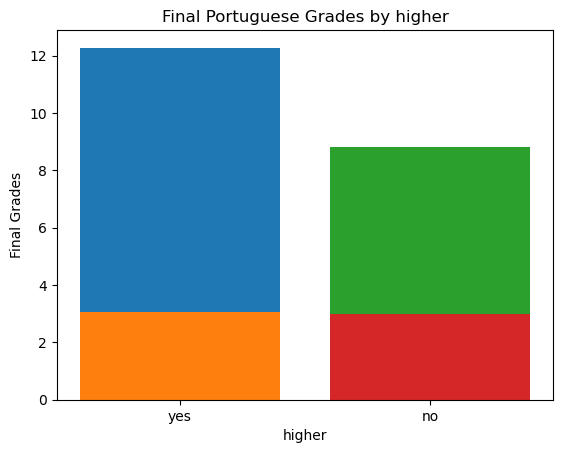

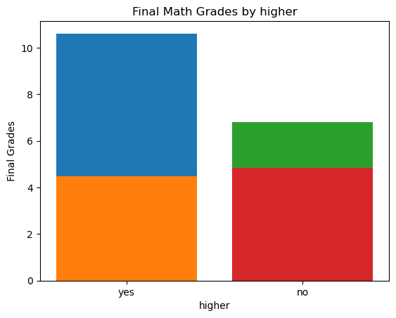

```python
plot_por_attribute('higher')
plot_math_attribute('higher')
```

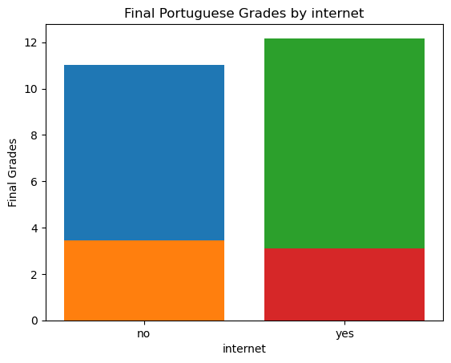

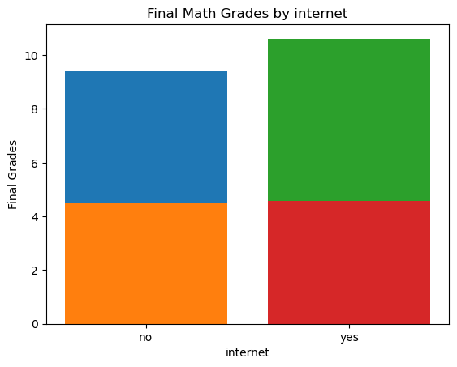

```python
plot_por_attribute('internet')
plot_math_attribute('internet')
```

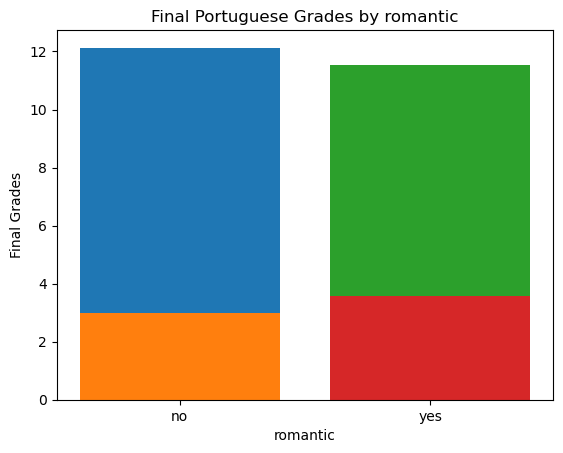

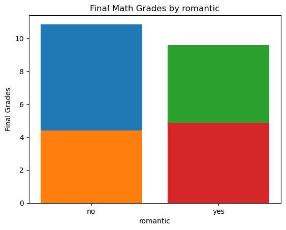

```python
plot_por_attribute('romantic')
plot_math_attribute('romantic')
```

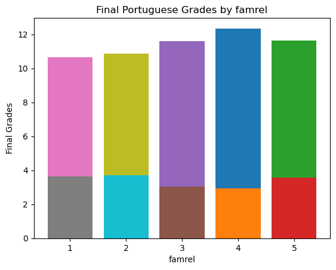

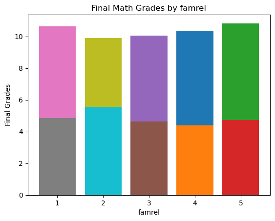

```python
plot_por_attribute('famrel')
plot_math_attribute('famrel')
```

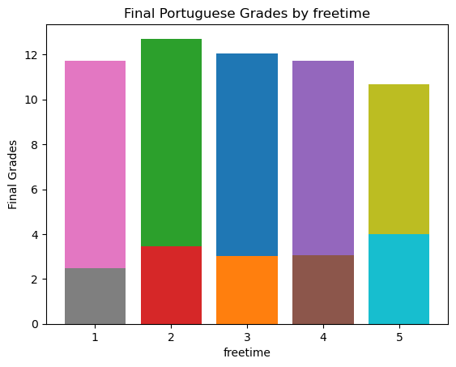

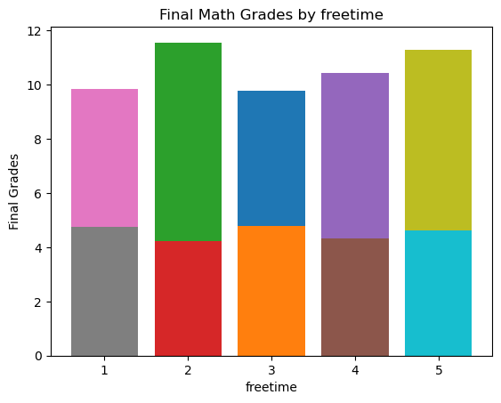

```python
plot_por_attribute('freetime')
plot_math_attribute('freetime')
```

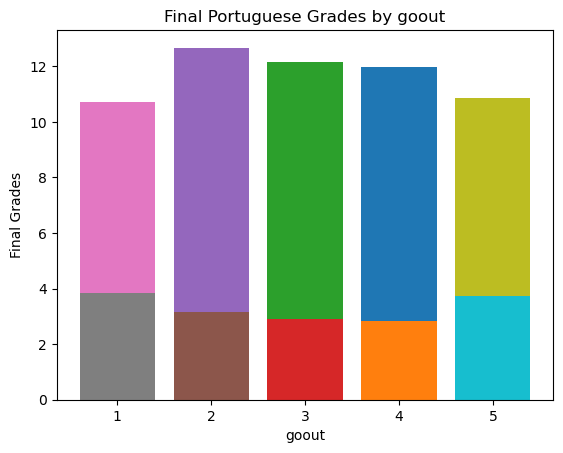

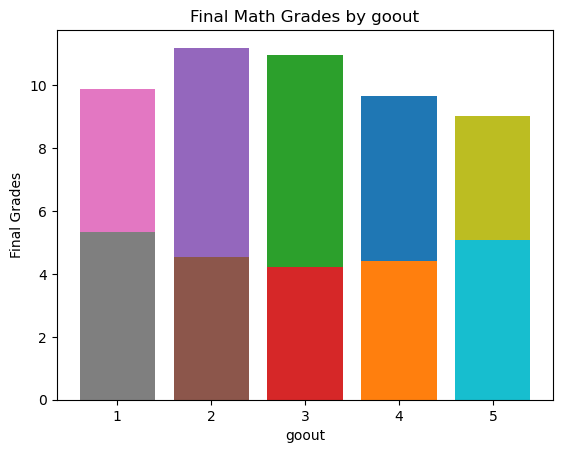

```python
plot_por_attribute('goout')
plot_math_attribute('goout')
```

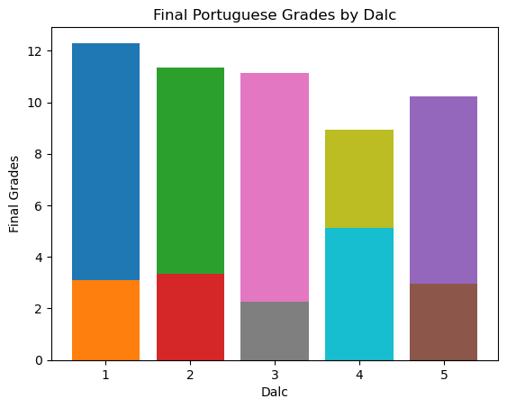

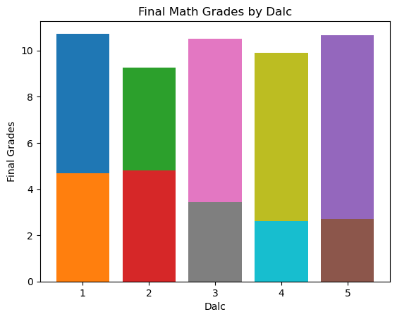

```python
plot_por_attribute('Dalc')
plot_math_attribute('Dalc')
```

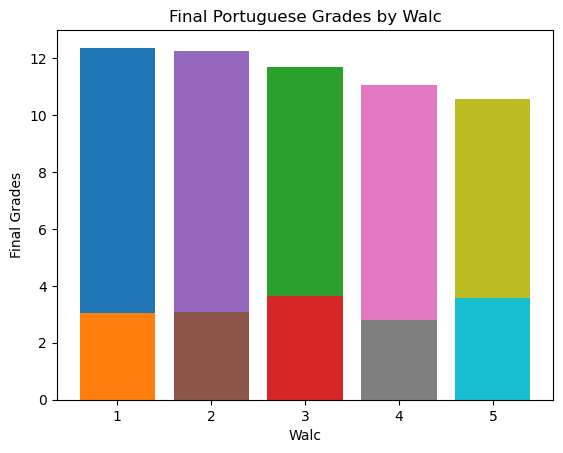

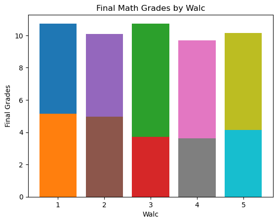

```python
plot_por_attribute('Walc')
plot_math_attribute('Walc')
```

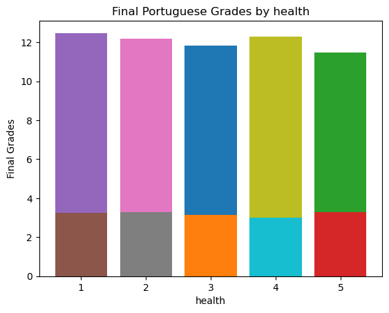

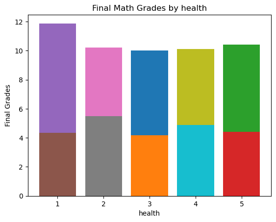

```python
plot_por_attribute('health')
plot_math_attribute('health')
```

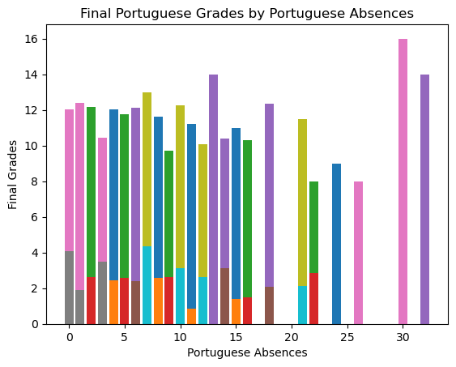

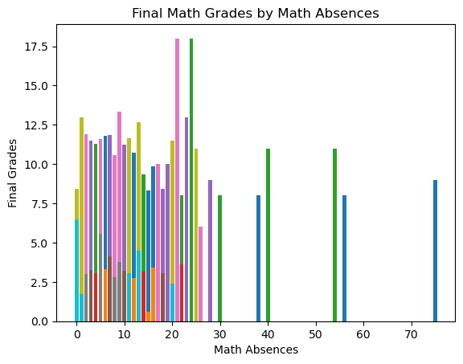

```python
plot_por_attribute('Portuguese Absences')
plot_math_attribute('Math Absences')
```

# Analysis, hypothesis testing, & ML

That was a lot of factors, and just off a quick glance you might be able to tell which factor impacts the dependent variable the most. But in order to make sure, we have to do some analysis and train a machine learning algorithm to calculate a value that associates with a factor's impact. We will use linear regresion to accomplish this task.

First we replace all binary columns with 1s and 0s because linear regression requires that all the data be in numbers, not in categorical data. Then, we use statsmodels.formula.api's ols method to calculate all the statistics we need to determine which factor explains the data the most. We do this twice, one for each dataset. Find out more about the ols method here at https://www.statsmodels.org/stable/generated/statsmodels.formula.api.ols.html

```python
por_dataframe.replace({"yes": 1, "no": 0, "GP": 1, "MS": 0, "M": 1, "F": 0}, inplace=True)
math_dataframe.replace({"yes": 1, "no": 0, "GP": 1, "MS": 0, "M": 1, "F": 0}, inplace=True)

formula = "Q('Portuguese Final Grade') ~ school + sex + age + address + famsize + Pstatus + Medu + Fedu + Mjob + \
reason + guardian + traveltime + studytime + Q('Failures Before Portuguese Class') + schoolsup + famsup + Q('Extra Paid Classes Within Portuguese') + \
activities + nursery + higher + internet + romantic + famrel + freetime + goout + Dalc + Walc + health + Q('Portuguese Absences')"
reg = smf.ols(formula=formula, data=por_dataframe).fit()
reg.summary()
```

OLS Regression Results

| Dep. Variable: | Q('Portuguese Final Grade') | R-squared: | 0.353 |
| --- | --- | --- | --- |
| Model: | OLS | Adj. R-squared: | 0.316 |
| Method: | Least Squares | F-statistic: | 9.537 |
| Date: | Sun, 19 May 2024 | Prob (F-statistic): | 1.01e-38 |
| Time: | 03:28:12 | Log-Likelihood: | -1540.4 |
| No. Observations: | 649 | AIC: | 3153. |
| Df Residuals: | 613 | BIC: | 3314. |
| Df Model: | 35 |  |  |
| Covariance Type: | nonrobust |  |  |

|  | coef | std err | t | P>\|t\| | [0.025 | 0.975] |
| --- | --- | --- | --- | --- | --- | --- |
| Intercept | 7.0674 | 1.944 | 3.636 | 0.000 | 3.251 | 10.884 |
| address[T.U] | 0.3056 | 0.262 | 1.169 | 0.243 | -0.208 | 0.819 |
| famsize[T.LE3] | 0.2763 | 0.245 | 1.128 | 0.260 | -0.205 | 0.757 |
| Pstatus[T.T] | 0.1224 | 0.347 | 0.353 | 0.724 | -0.559 | 0.804 |
| Mjob[T.health] | 0.7415 | 0.528 | 1.404 | 0.161 | -0.296 | 1.779 |
| Mjob[T.other] | 0.0571 | 0.302 | 0.189 | 0.850 | -0.536 | 0.650 |
| Mjob[T.services] | 0.3156 | 0.369 | 0.856 | 0.393 | -0.409 | 1.040 |
| Mjob[T.teacher] | 0.5258 | 0.495 | 1.063 | 0.288 | -0.446 | 1.497 |
| reason[T.home] | 0.0602 | 0.285 | 0.211 | 0.833 | -0.500 | 0.620 |
| reason[T.other] | -0.4683 | 0.367 | -1.278 | 0.202 | -1.188 | 0.251 |
| reason[T.reputation] | 0.2162 | 0.298 | 0.726 | 0.468 | -0.368 | 0.801 |
| guardian[T.mother] | -0.3176 | 0.264 | -1.202 | 0.230 | -0.836 | 0.201 |
| guardian[T.other] | 0.0976 | 0.531 | 0.184 | 0.854 | -0.945 | 1.140 |
| school | 1.2459 | 0.264 | 4.713 | 0.000 | 0.727 | 1.765 |
| sex | -0.6168 | 0.250 | -2.464 | 0.014 | -1.108 | -0.125 |
| age | 0.1692 | 0.102 | 1.656 | 0.098 | -0.031 | 0.370 |
| Medu | 0.0686 | 0.151 | 0.455 | 0.649 | -0.228 | 0.365 |
| Fedu | 0.1887 | 0.130 | 1.448 | 0.148 | -0.067 | 0.445 |
| traveltime | 0.0849 | 0.158 | 0.536 | 0.592 | -0.226 | 0.396 |
| studytime | 0.3710 | 0.139 | 2.663 | 0.008 | 0.097 | 0.645 |
| Q('Failures Before Portuguese Class') | -1.4272 | 0.205 | -6.967 | 0.000 | -1.830 | -1.025 |
| schoolsup | -1.2481 | 0.363 | -3.440 | 0.001 | -1.961 | -0.536 |
| famsup | -0.0159 | 0.228 | -0.070 | 0.944 | -0.464 | 0.432 |
| Q('Extra Paid Classes Within Portuguese') | -0.3965 | 0.461 | -0.859 | 0.390 | -1.302 | 0.509 |
| activities | 0.2179 | 0.223 | 0.976 | 0.330 | -0.221 | 0.657 |
| nursery | -0.2367 | 0.272 | -0.872 | 0.384 | -0.770 | 0.297 |
| higher | 1.7208 | 0.383 | 4.495 | 0.000 | 0.969 | 2.473 |
| internet | 0.2150 | 0.275 | 0.781 | 0.435 | -0.326 | 0.756 |
| romantic | -0.4067 | 0.229 | -1.774 | 0.077 | -0.857 | 0.044 |
| famrel | 0.1295 | 0.116 | 1.119 | 0.263 | -0.098 | 0.357 |
| freetime | -0.1212 | 0.112 | -1.080 | 0.280 | -0.342 | 0.099 |
| goout | -0.0534 | 0.107 | -0.497 | 0.619 | -0.264 | 0.157 |
| Dalc | -0.2162 | 0.153 | -1.413 | 0.158 | -0.517 | 0.084 |
| Walc | -0.1170 | 0.118 | -0.995 | 0.320 | -0.348 | 0.114 |
| health | -0.1754 | 0.077 | -2.292 | 0.022 | -0.326 | -0.025 |
| Q('Portuguese Absences') | -0.0376 | 0.025 | -1.511 | 0.131 | -0.086 | 0.011 |

| Omnibus: | 125.216 | Durbin-Watson: | 1.908 |
| --- | --- | --- | --- |
| Prob(Omnibus): | 0.000 | Jarque-Bera (JB): | 404.464 |
| Skew: | -0.904 | Prob(JB): | 1.48e-88 |
| Kurtosis: | 6.419 | Cond. No. | 361. |

Notes:  
[1] Standard Errors assume that the covariance matrix of the errors is correctly specified.

```python
formula2 = "Q('Math Final Grade') ~ school + sex + age + address + famsize + Pstatus + Medu + Fedu + Mjob + \
reason + guardian + traveltime + studytime + Q('Failures Before Math Class') + schoolsup + famsup + Q('Extra Paid Classes Within Math') + \
activities + nursery + higher + internet + romantic + famrel + freetime + goout + Dalc + Walc + health + Q('Math Absences')"
reg2 = smf.ols(formula=formula2, data=math_dataframe).fit()
reg2.summary()
```

OLS Regression Results

| Dep. Variable: | Q('Math Final Grade') | R-squared: | 0.266 |
| --- | --- | --- | --- |
| Model: | OLS | Adj. R-squared: | 0.194 |
| Method: | Least Squares | F-statistic: | 3.714 |
| Date: | Sun, 19 May 2024 | Prob (F-statistic): | 1.38e-10 |
| Time: | 02:16:21 | Log-Likelihood: | -1100.1 |
| No. Observations: | 395 | AIC: | 2272. |
| Df Residuals: | 359 | BIC: | 2416. |
| Df Model: | 35 |  |  |
| Covariance Type: | nonrobust |  |  |

|  | coef | std err | t | P>\|t\| | [0.025 | 0.975] |
| --- | --- | --- | --- | --- | --- | --- |
| Intercept | 14.0998 | 4.587 | 3.074 | 0.002 | 5.080 | 23.120 |
| address[T.U] | 0.5758 | 0.584 | 0.987 | 0.324 | -0.572 | 1.724 |
| famsize[T.LE3] | 0.6599 | 0.486 | 1.358 | 0.175 | -0.296 | 1.616 |
| Pstatus[T.T] | -0.4058 | 0.722 | -0.562 | 0.575 | -1.827 | 1.015 |
| Mjob[T.health] | 0.9767 | 1.093 | 0.894 | 0.372 | -1.172 | 3.126 |
| Mjob[T.other] | -0.4355 | 0.705 | -0.617 | 0.537 | -1.823 | 0.952 |
| Mjob[T.services] | 0.6903 | 0.784 | 0.880 | 0.379 | -0.852 | 2.232 |
| Mjob[T.teacher] | -0.9824 | 1.012 | -0.971 | 0.332 | -2.973 | 1.008 |
| reason[T.home] | 0.1031 | 0.554 | 0.186 | 0.852 | -0.986 | 1.192 |
| reason[T.other] | 1.0074 | 0.809 | 1.245 | 0.214 | -0.584 | 2.598 |
| reason[T.reputation] | 0.6577 | 0.574 | 1.146 | 0.253 | -0.471 | 1.786 |
| guardian[T.mother] | -0.0379 | 0.537 | -0.071 | 0.944 | -1.093 | 1.017 |
| guardian[T.other] | 0.5026 | 0.992 | 0.507 | 0.613 | -1.448 | 2.453 |
| school | -0.6498 | 0.784 | -0.829 | 0.408 | -2.191 | 0.891 |
| sex | 1.2744 | 0.499 | 2.553 | 0.011 | 0.293 | 2.256 |
| age | -0.3574 | 0.216 | -1.656 | 0.099 | -0.782 | 0.067 |
| Medu | 0.4365 | 0.318 | 1.374 | 0.170 | -0.188 | 1.061 |
| Fedu | 0.0701 | 0.263 | 0.266 | 0.790 | -0.448 | 0.588 |
| traveltime | -0.2149 | 0.335 | -0.641 | 0.522 | -0.874 | 0.444 |
| studytime | 0.5536 | 0.285 | 1.942 | 0.053 | -0.007 | 1.114 |
| Q('Failures Before Math Class') | -1.6939 | 0.332 | -5.108 | 0.000 | -2.346 | -1.042 |
| schoolsup | -1.2173 | 0.664 | -1.834 | 0.068 | -2.523 | 0.088 |
| famsup | -0.8395 | 0.478 | -1.756 | 0.080 | -1.780 | 0.101 |
| Q('Extra Paid Classes Within Math') | 0.2595 | 0.476 | 0.545 | 0.586 | -0.677 | 1.196 |
| activities | -0.4048 | 0.442 | -0.916 | 0.360 | -1.274 | 0.464 |
| nursery | -0.1883 | 0.547 | -0.344 | 0.731 | -1.263 | 0.887 |
| higher | 1.3722 | 1.074 | 1.277 | 0.202 | -0.740 | 3.485 |
| internet | 0.3847 | 0.614 | 0.626 | 0.532 | -0.823 | 1.593 |
| romantic | -1.0324 | 0.468 | -2.204 | 0.028 | -1.954 | -0.111 |
| famrel | 0.1808 | 0.243 | 0.743 | 0.458 | -0.298 | 0.660 |
| freetime | 0.3028 | 0.235 | 1.291 | 0.198 | -0.158 | 0.764 |
| goout | -0.5734 | 0.224 | -2.556 | 0.011 | -1.015 | -0.132 |
| Dalc | -0.2081 | 0.326 | -0.638 | 0.524 | -0.850 | 0.434 |
| Walc | 0.1631 | 0.243 | 0.672 | 0.502 | -0.314 | 0.641 |
| health | -0.1632 | 0.160 | -1.019 | 0.309 | -0.478 | 0.152 |
| Q('Math Absences') | 0.0548 | 0.029 | 1.894 | 0.059 | -0.002 | 0.112 |

| Omnibus: | 28.951 | Durbin-Watson: | 2.060 |
| --- | --- | --- | --- |
| Prob(Omnibus): | 0.000 | Jarque-Bera (JB): | 33.237 |
| Skew: | -0.672 | Prob(JB): | 6.06e-08 |
| Kurtosis: | 3.461 | Cond. No. | 450. |

Notes:  
[1] Standard Errors assume that the covariance matrix of the errors is correctly specified.